# Научная презентация 11

Дисциплина:Операционные системы

Алехин Давид Андреевич

Российский университет дружбы народов, Москва, Россия

Математический институт имени Никольского, Москва, Россия

06.03.25

# Информация

## Докладчик

- Алехин Давид Андреевич
- Студент
- Студент НММбд-01-24
- Российский университет дружбы народов
- 1132246830@pfur.ru
- https://github.com/trustdef

[figure not shown]

# Элементы презентации

## Актуальность

- Важно уметь работать с emacs.

## Цели и задачи

- Познакомиться с операционной системой Linux. Получить практические навыки работы с редактором Emacs.

## Материалы и методы

- fedora-linux
- emacs

## Содержание исследования

Откроем Emacs (рис. [-@fig:001]).

[figure not shown]

1

## Содержание исследования

Создадим файл lab07.sh с помощью комбинации Ctrl-x Ctrl-f и наберем текст из задания в ново созданный файл. (рис. [-@fig:002]).

[figure not shown]

2

## Содержание исследования

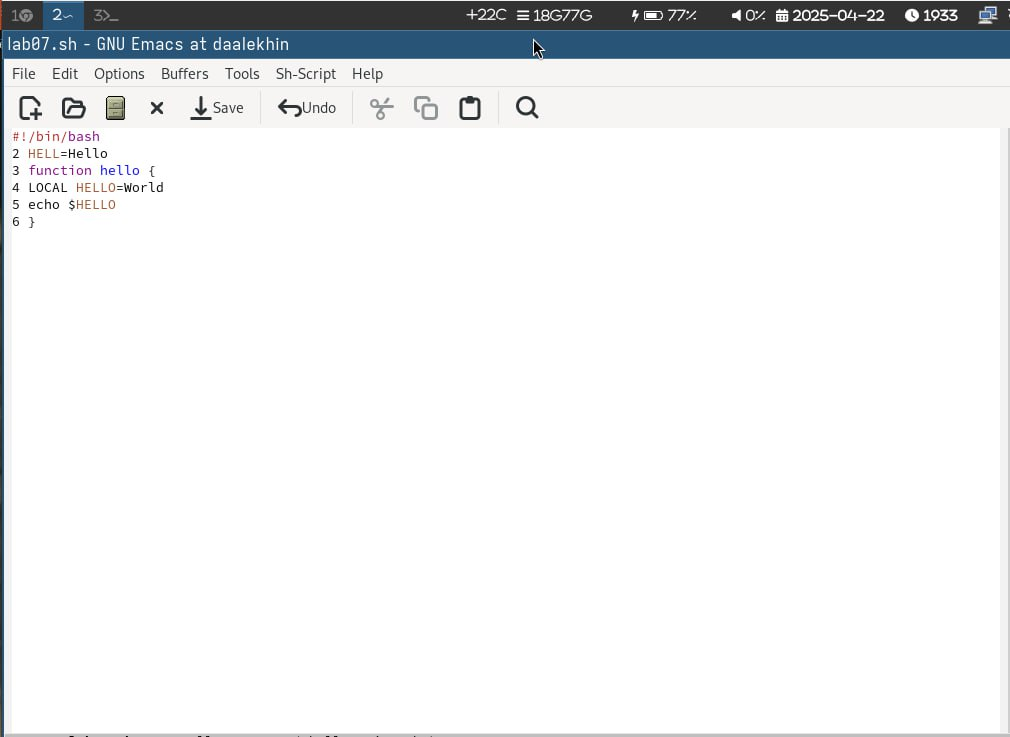

3

## Содержание исследования

Выделим область текста командой Ctrl-space. (рис. [-@fig:004]).

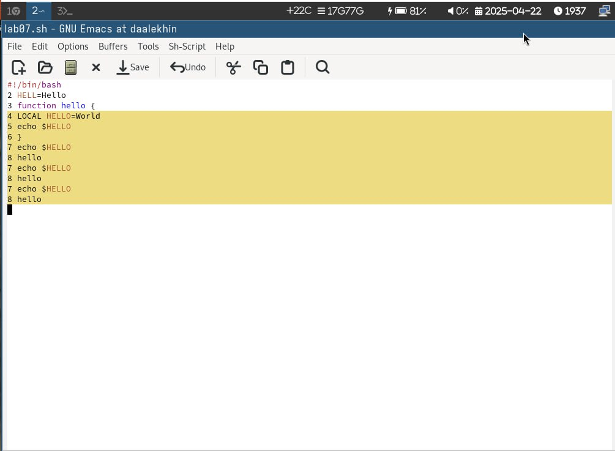

4

## Содержание исследования

Скопируем область в буфер обмена командой alt-w. Вставим область в конец файла. (рис. [-@fig:005]).

[figure not shown]

5

## Содержание исследования

Вновь выделим эту область и на этот раз вырежем её командой Ctrl-w. (рис. [-@fig:006]).

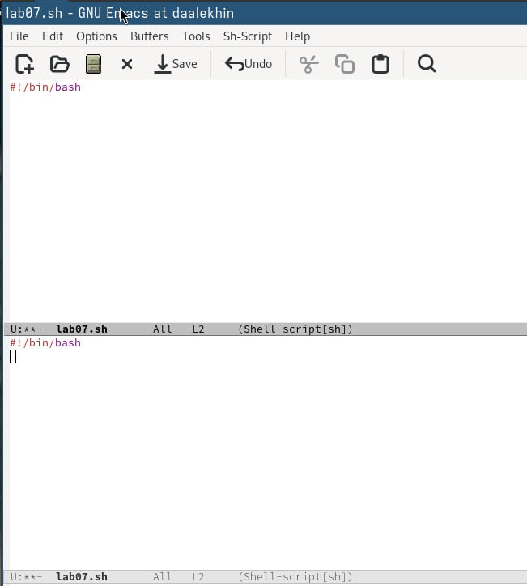

6

## Содержание исследования

Отменим последнее действие командой Ctrl-x u. Научимся использовать команды по перемещению курсора.

```
Переместим курсор в начало строки командой Ctrl-a.

Переместим курсор в курсор строки командой Ctrl-e.

Переместим курсор в начало буфера Alt-<.

Переместим курсор в конец буфера Alt->.
```

## Содержание исследования

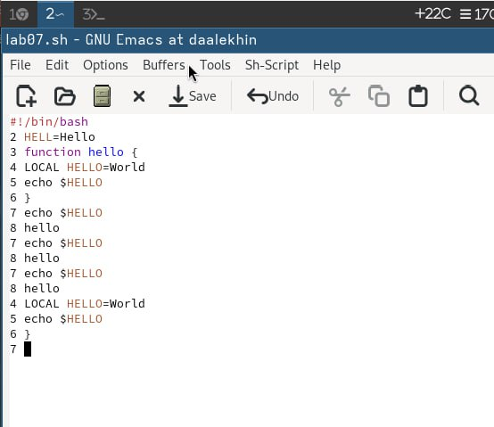

7

## Содержание исследования

Переместим вновь открытое окно Ctrl-x со списком открытых буферов и переключимся на другой буфер. (рис. [-@fig:008]).

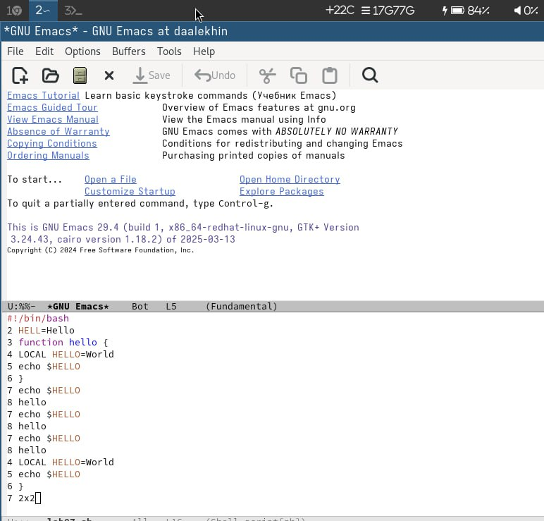

8

## Содержание исследования

Закроем это окно командой Ctrl-x 0. (рис. [-@fig:009]).

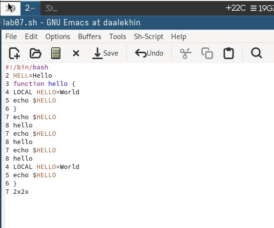

9

## Содержание исследования

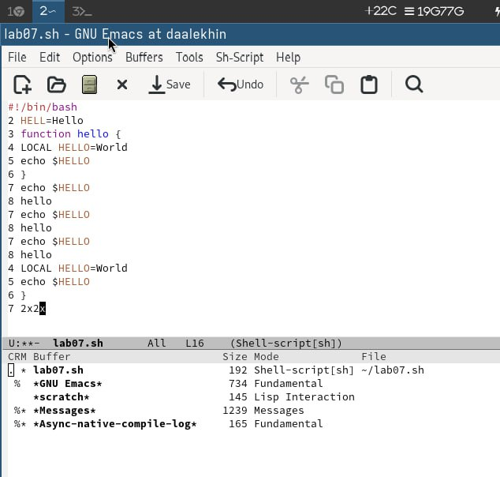

10

## Содержание исследования

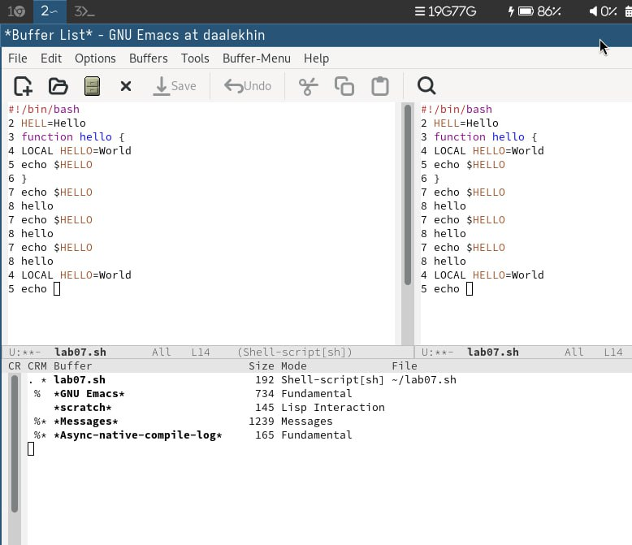

11

## Содержание исследования

Переключимся в режим поиска Ctrl-s и найдем несколько слов, присутствующих в тексте. Выйдем из режима поиска, нажав Ctrl-g. Перейдем в режим поиска и замены Alt-Shift %, введем текст, который следует найти и заменить, для замены нажмем Enter. После этого нажмем ! для подтверждения замены. Если мы хотим заменить конкретные слова то мы их выделяем и нажимаем Enter. Если все то ! Испробуем другой режим поиска, нажав Alt-s . От обычного режима отличается тем, что находит не фрагмент текста, а файл.

## Результаты

В данной работе мы познакомились с еще одним редактором операционной системой Linux. Получили практические навыки работы с редактором Emacs.

## Итоговый слайд

В теории, теория и практика неразделимы. На практике это не так. Yoggi Berra

:::